# Ford Go Bike System Data Analysis

## Introduction

> This data set includes information about individual rides made in a bike-sharing system covering the greater San Francisco Bay area. The data contains 183412 rows and 16 columns. Some of the columns in this data include *duration_sec*, *start_station_id*, *start_station_latitude*, *start_station_longitude*, *end_station_id*, *end_station_latitude*, *end_station_longitude*, *bike_id*, *member_birth_year* etc.

## Preliminary Wrangling

```python
# import all packages and set plots to be embedded inline
import numpy as np
import pandas as pd
import matplotlib.pyplot as plt
import seaborn as sb

%matplotlib inline
```

## Assessing Data

> Vissual and programmatic assessment is carried out on the fordgobike-tripdata.

```python
# Load data
trip_df = pd.read_csv('fordgobike-tripdata.csv')
trip_df.head()
```

|  | duration_sec | start_time | end_time | start_station_id | start_station_name | start_station_latitude | start_station_longitude | end_station_id | end_station_name | end_station_latitude | end_station_longitude | bike_id | user_type | member_birth_year | member_gender | bike_share_for_all_trip |
| --- | --- | --- | --- | --- | --- | --- | --- | --- | --- | --- | --- | --- | --- | --- | --- | --- |
| 0 | 52185 | 2019-02-28 17:32:10.1450 | 2019-03-01 08:01:55.9750 | 21.0 | Montgomery St BART Station (Market St at 2nd St) | 37.789625 | -122.400811 | 13.0 | Commercial St at Montgomery St | 37.794231 | -122.402923 | 4902 | Customer | 1984.0 | Male | No |
| 1 | 42521 | 2019-02-28 18:53:21.7890 | 2019-03-01 06:42:03.0560 | 23.0 | The Embarcadero at Steuart St | 37.791464 | -122.391034 | 81.0 | Berry St at 4th St | 37.775880 | -122.393170 | 2535 | Customer | NaN | NaN | No |
| 2 | 61854 | 2019-02-28 12:13:13.2180 | 2019-03-01 05:24:08.1460 | 86.0 | Market St at Dolores St | 37.769305 | -122.426826 | 3.0 | Powell St BART Station (Market St at 4th St) | 37.786375 | -122.404904 | 5905 | Customer | 1972.0 | Male | No |
| 3 | 36490 | 2019-02-28 17:54:26.0100 | 2019-03-01 04:02:36.8420 | 375.0 | Grove St at Masonic Ave | 37.774836 | -122.446546 | 70.0 | Central Ave at Fell St | 37.773311 | -122.444293 | 6638 | Subscriber | 1989.0 | Other | No |
| 4 | 1585 | 2019-02-28 23:54:18.5490 | 2019-03-01 00:20:44.0740 | 7.0 | Frank H Ogawa Plaza | 37.804562 | -122.271738 | 222.0 | 10th Ave at E 15th St | 37.792714 | -122.248780 | 4898 | Subscriber | 1974.0 | Male | Yes |

```python
# Check information
trip_df.info()
```

```
<class 'pandas.core.frame.DataFrame'>
RangeIndex: 183412 entries, 0 to 183411
Data columns (total 16 columns):
 #   Column                   Non-Null Count   Dtype
---  ------                   --------------   -----
 0   duration_sec             183412 non-null  int64
 1   start_time               183412 non-null  object
 2   end_time                 183412 non-null  object
 3   start_station_id         183215 non-null  float64
 4   start_station_name       183215 non-null  object
 5   start_station_latitude   183412 non-null  float64
 6   start_station_longitude  183412 non-null  float64
 7   end_station_id           183215 non-null  float64
 8   end_station_name         183215 non-null  object
 9   end_station_latitude     183412 non-null  float64
 10  end_station_longitude    183412 non-null  float64
 11  bike_id                  183412 non-null  int64
 12  user_type                183412 non-null  object
 13  member_birth_year        175147 non-null  float64
 14  member_gender            175147 non-null  object
 15  bike_share_for_all_trip  183412 non-null  object
dtypes: float64(7), int64(2), object(7)
memory usage: 22.4+ MB
```

```python
# Check data statistics
trip_df.describe()
```

|  | duration_sec | start_station_id | start_station_latitude | start_station_longitude | end_station_id | end_station_latitude | end_station_longitude | bike_id | member_birth_year |
| --- | --- | --- | --- | --- | --- | --- | --- | --- | --- |
| count | 183412.000000 | 183215.000000 | 183412.000000 | 183412.000000 | 183215.000000 | 183412.000000 | 183412.000000 | 183412.000000 | 175147.000000 |
| mean | 726.078435 | 138.590427 | 37.771223 | -122.352664 | 136.249123 | 37.771427 | -122.352250 | 4472.906375 | 1984.806437 |
| std | 1794.389780 | 111.778864 | 0.099581 | 0.117097 | 111.515131 | 0.099490 | 0.116673 | 1664.383394 | 10.116689 |
| min | 61.000000 | 3.000000 | 37.317298 | -122.453704 | 3.000000 | 37.317298 | -122.453704 | 11.000000 | 1878.000000 |
| 25% | 325.000000 | 47.000000 | 37.770083 | -122.412408 | 44.000000 | 37.770407 | -122.411726 | 3777.000000 | 1980.000000 |
| 50% | 514.000000 | 104.000000 | 37.780760 | -122.398285 | 100.000000 | 37.781010 | -122.398279 | 4958.000000 | 1987.000000 |
| 75% | 796.000000 | 239.000000 | 37.797280 | -122.286533 | 235.000000 | 37.797320 | -122.288045 | 5502.000000 | 1992.000000 |
| max | 85444.000000 | 398.000000 | 37.880222 | -121.874119 | 398.000000 | 37.880222 | -121.874119 | 6645.000000 | 2001.000000 |

```python
# Check for duplicates
trip_df.duplicated().sum()
```

```
0
```

```python
# Check for null values
trip_df.isnull().sum()
```

```
duration_sec                  0
start_time                    0
end_time                      0
start_station_id            197
start_station_name          197
start_station_latitude        0
start_station_longitude       0
end_station_id              197
end_station_name            197
end_station_latitude          0
end_station_longitude         0
bike_id                       0
user_type                     0
member_birth_year          8265
member_gender              8265
bike_share_for_all_trip       0
dtype: int64
```

```python
# Check min and max of borth year
#trip_df.member_birth_year.min()
trip_df.member_birth_year.value_counts()
```

```
1988.0    10236
1993.0     9325
1989.0     8972
1990.0     8658
1991.0     8498
          ...
1928.0        1
1878.0        1
1930.0        1
1910.0        1
1927.0        1
Name: member_birth_year, Length: 75, dtype: int64
```

```python
# Check types of gender
trip_df.member_gender.value_counts()
```

```
Male      130651
Female     40844
Other       3652
Name: member_gender, dtype: int64
```

```python
# Check start time
trip_df.start_time
```

```
0         2019-02-28 17:32:10.1450
1         2019-02-28 18:53:21.7890
2         2019-02-28 12:13:13.2180
3         2019-02-28 17:54:26.0100
4         2019-02-28 23:54:18.5490
                    ...
183407    2019-02-01 00:04:49.7240
183408    2019-02-01 00:05:34.7440
183409    2019-02-01 00:06:05.5490
183410    2019-02-01 00:05:34.3600
183411    2019-02-01 00:00:20.6360
Name: start_time, Length: 183412, dtype: object
```

### Quality issues

1. Erroneous datatypes (start_time, end_time, bike_id)
2. Null values in these colums (start_station_id, start_station_name, end_station_id, end_station_name, member_birth_year, member_gender).
3. Duration is in seconds

```python
# Creat a copy of data
trip_clean_df = trip_df.copy()
trip_clean_df.sample(3)
```

|  | duration_sec | start_time | end_time | start_station_id | start_station_name | start_station_latitude | start_station_longitude | end_station_id | end_station_name | end_station_latitude | end_station_longitude | bike_id | user_type | member_birth_year | member_gender | bike_share_for_all_trip |
| --- | --- | --- | --- | --- | --- | --- | --- | --- | --- | --- | --- | --- | --- | --- | --- | --- |
| 46387 | 274 | 2019-02-22 09:53:54.4960 | 2019-02-22 09:58:29.4010 | 58.0 | Market St at 10th St | 37.776619 | -122.417385 | 88.0 | 11th St at Bryant St | 37.770030 | -122.411726 | 1718 | Subscriber | 1983.0 | Male | No |
| 97396 | 953 | 2019-02-15 08:50:35.7040 | 2019-02-15 09:06:29.2170 | 15.0 | San Francisco Ferry Building (Harry Bridges Pl... | 37.795392 | -122.394203 | 350.0 | 8th St at Brannan St | 37.771431 | -122.405787 | 6299 | Subscriber | 1984.0 | Female | No |
| 69741 | 533 | 2019-02-19 19:01:37.6460 | 2019-02-19 19:10:31.4280 | 113.0 | Franklin Square | 37.764555 | -122.410345 | 130.0 | 22nd St Caltrain Station | 37.757288 | -122.392051 | 6535 | Subscriber | 1995.0 | Male | No |

## Cleaning Data

#### Define:

1. Drop all rows with null values.
2. Correct all erroneous datatypes.
3. Create column for duration in minutes.
4. Drop all columns not needed in the analysis.

#### Code

```python
# Drop all rows with null values
trip_clean_df = trip_df.dropna()
```

```python
# Coorect all erroneos datatypes
trip_clean_df.start_time = pd.to_datetime(trip_clean_df.start_time)
trip_clean_df.end_time = pd.to_datetime(trip_clean_df.end_time)
trip_clean_df.start_station_id = trip_clean_df.start_station_id.astype(str)
trip_clean_df.end_station_id = trip_clean_df.end_station_id.astype(str)
trip_clean_df.bike_id = trip_clean_df.bike_id.astype(str)
```

```python
# Convert duration to minutes
trip_clean_df['duration_min'] = trip_clean_df.duration_sec/60
```

```python
# Drop all columns not needed in the analysis
trip_clean_df = trip_clean_df.drop(trip_clean_df[['bike_id','start_time','end_time','start_station_latitude',
                                     'start_station_longitude','end_station_latitude',
                                     'end_station_longitude']], axis=1)
```

#### Test

```python
# Test changes
trip_clean_df.isna().sum()
```

```
duration_sec               0
start_station_id           0
start_station_name         0
end_station_id             0
end_station_name           0
user_type                  0
member_birth_year          0
member_gender              0
bike_share_for_all_trip    0
duration_min               0
dtype: int64
```

```python
# Test changes
trip_clean_df.info()
```

```
<class 'pandas.core.frame.DataFrame'>
Int64Index: 174952 entries, 0 to 183411
Data columns (total 10 columns):
 #   Column                   Non-Null Count   Dtype
---  ------                   --------------   -----
 0   duration_sec             174952 non-null  int64
 1   start_station_id         174952 non-null  object
 2   start_station_name       174952 non-null  object
 3   end_station_id           174952 non-null  object
 4   end_station_name         174952 non-null  object
 5   user_type                174952 non-null  object
 6   member_birth_year        174952 non-null  float64
 7   member_gender            174952 non-null  object
 8   bike_share_for_all_trip  174952 non-null  object
 9   duration_min             174952 non-null  float64
dtypes: float64(2), int64(1), object(7)
memory usage: 14.7+ MB
```

### What is the structure of your dataset?

> The data contains 183412 rows and 16 columns. Some of the columns in this data include *duration_sec*, *start_station_id*, *start_station_latitude*, *start_station_longitude*, *end_station_id*, *end_station_latitude*, *end_station_longitude*, *bike_id*, *member_birth_year* etc.

### What is/are the main feature(s) of interest in your dataset?

> I am more interested in how trip duration is dependent on other features of the data.

### What features in the dataset do you think will help support your investigation into your feature(s) of interest?

> My expectations are that trip duration should depend on features such birth year, user type, gender, start station and end station.

## Univariate Exploration

> I will start by looking at the distribution of duration.

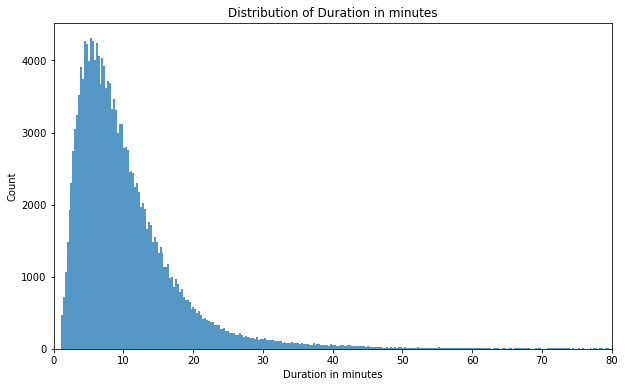

```python
# Distribution of duration in minutes
plt.figure(figsize=(10,6))
x= trip_clean_df.duration_min
sb.histplot(x);
plt.title('Distribution of Duration in minutes');
plt.xlabel('Duration in minutes');
plt.xlim(0,80);
```

The Next feature I will investigate the user type column.

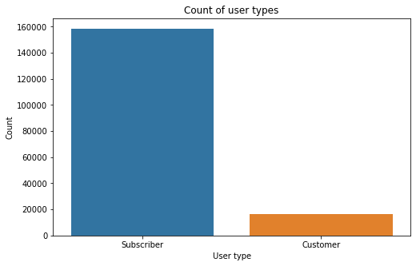

```python
# User types
plt.figure(figsize=(8,5))
x =  trip_clean_df.user_type.value_counts().index
y = trip_clean_df.user_type.value_counts().values
sb.barplot(data=trip_clean_df, x=x, y=y)
plt.title('Count of user types');
plt.xlabel('User type');
plt.ylabel('Count');
```

We can see that larger number of users in the bikeshare system are subcribers.

Next up, I will look at the types of gender in the system.

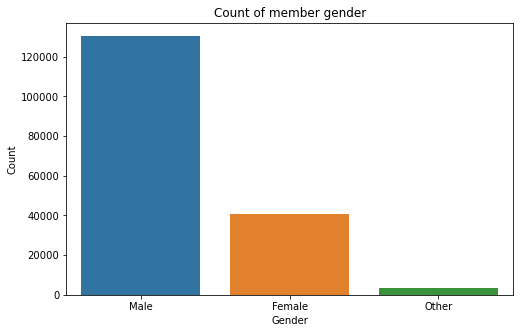

```python
# Member gender
plt.figure(figsize=(8,5))
x = trip_clean_df.member_gender.value_counts().index
y = trip_clean_df.member_gender.value_counts().values
sb.barplot(data=trip_clean_df, x= x, y=y)
plt.title('Count of member gender');
plt.xlabel('Gender');
plt.ylabel('Count');
```

We can see that in terms of gender, males use the bikeshare system more than both females and other gender.

Next up, I will look at the top 20 user start stations and user end stations.

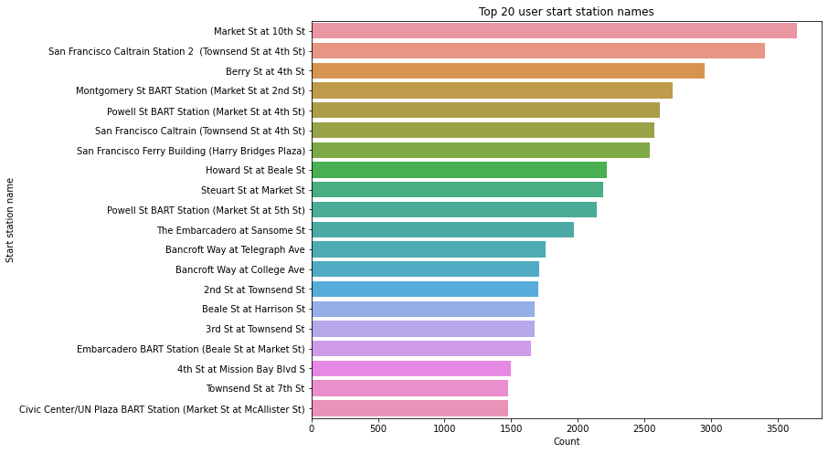

```python
# Top 20 start stations
plt.figure(figsize=(10,8))
x = trip_clean_df.start_station_name.value_counts()[:20].index
y = trip_clean_df.start_station_name.value_counts()[:20].values
sb.barplot(x=y ,y=x)
plt.title('Top 20 user start station names');
plt.xlabel('Count');
plt.ylabel('Start station name');
```

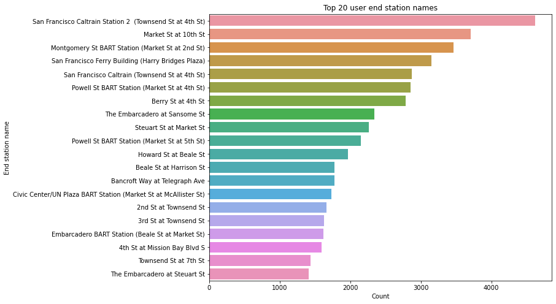

```python
# Top 20 end stations
plt.figure(figsize=(10,8))
x = trip_clean_df.end_station_name.value_counts()[:20].index
y = trip_clean_df.end_station_name.value_counts()[:20].values
sb.barplot(x=y ,y=x)
plt.title('Top 20 user end station names');
plt.xlabel('Count');
plt.ylabel('End station name');
```

Users are more likely to end their journey at San Francisco Cultrain Station 2 (Townsend St at 4thSt).

Now I will look at the distribution of member birth year.

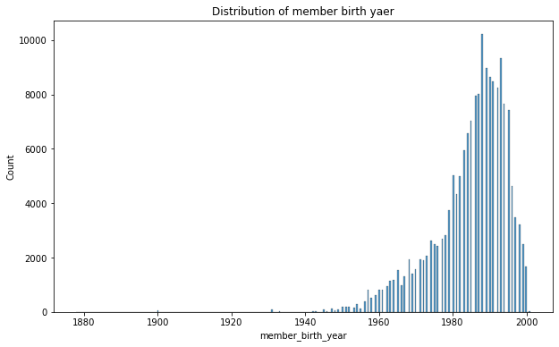

```python
# member birth year distribution
plt.figure(figsize=(10,6))
sb.histplot(data=trip_clean_df, x='member_birth_year');
plt.title('Distribution of member birth yaer');
```

The distribution is left skewed. Looks like there are outliers. Looking at this in terms of age will provide more insight.

```python
# Create user age column
trip_clean_df['member_age'] = 2019-trip_clean_df.member_birth_year
trip_clean_df.member_age.value_counts().sort_index(ascending=False)
```

```
141.0       1
119.0      53
118.0       6
117.0      11
109.0       1
         ...
22.0     3476
21.0     3208
20.0     2504
19.0     1675
18.0       34
Name: member_age, Length: 75, dtype: int64
```

[figure not shown]

```python
# member age distribution
plt.figure(figsize=(8,5))
sb.histplot(data=trip_clean_df, x='member_age');
plt.xlim(30,145);
plt.title('Distribution of age');
```

There is an outlier in the data with user having age of 141 years.

Next up, i will look at the number of members in the bikeshare for all program.

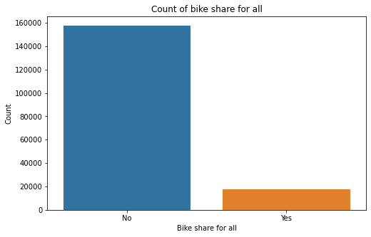

```python
# Create barplot for Bike share for all
plt.figure(figsize=(8,5))
x = trip_clean_df.bike_share_for_all_trip.value_counts().index
y = trip_clean_df.bike_share_for_all_trip.value_counts().values
sb.barplot(data = trip_clean_df, x=x ,y= y)
plt.title('Count of bike share for all');
plt.xlabel('Bike share for all');
plt.ylabel('Count');
```

### Discuss the distribution(s) of your variable(s) of interest. Were there any unusual points? Did you need to perform any transformations?

> Duration in seconds was converted to minutes for easy understanding of the values.

### Of the features you investigated, were there any unusual distributions? Did you perform any operations on the data to tidy, adjust, or change the form of the data? If so, why did you do this?

> Member age in 2019 column was created using member birth year. This was done to make user age interpretation easy.

Now, I will remove the row where there is an age outlier.

```python
# Remove outlier
trip_clean_df.drop([27370], axis=0, inplace=True)
trip_clean_df.member_age.max()
```

```
119.0
```

## Bivariate Exploration

> In this section, I will investigate relationships between pairs of variables in the data.

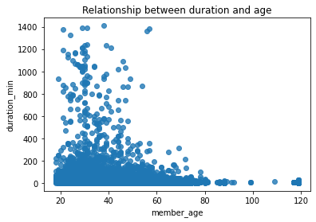

```python
# Relationship between user age and duration in minutes
sb.regplot(data = trip_clean_df, x='member_age', y='duration_min',
           x_jitter= 0.04, fit_reg=False)
plt.title('Relationship between duration and age');
```

Users having long durations are between the ages of 25 and 45.

Next up, I will look at the the relationship between duration and gender.

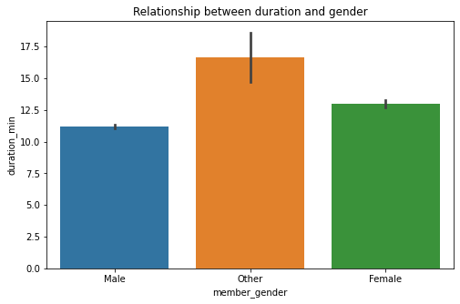

```python
# Relationship between gender and duration
plt.figure(figsize=(8,5))
x = trip_clean_df.member_gender
y = trip_clean_df.duration_min
sb.barplot(x=x ,y=y)
plt.title('Relationship between duration and gender');
```

The plot shows that users with other gender have longer ride duration, followed by females and males respectively.

Next up, I will look at the relationship between duration and user type.

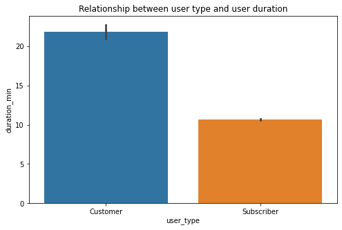

```python
# Relationship between user type and duration
plt.figure(figsize=(8,5))
x = trip_clean_df.user_type
y = trip_clean_df.duration_min
sb.barplot(data=trip_clean_df, x=x ,y=y)
plt.title('Relationship between user type and user duration');
```

We can see from the plot that, users who are customers have longer ride duration than subscribers.

Next up: Relationship between user type and gender.

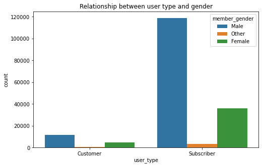

```python
# Relationship between user type and gender
plt.figure(figsize=(8,5))
sb.countplot(data=trip_clean_df, x='user_type', hue='member_gender');
plt.title('Relationship between user type and gender');
```

We can see from the plot that, Among the subscribers, there were more males than females and other genders. Also among the customer users, number of males appear to be higher than females and other genders.

This can also be viewed in a different visualization.

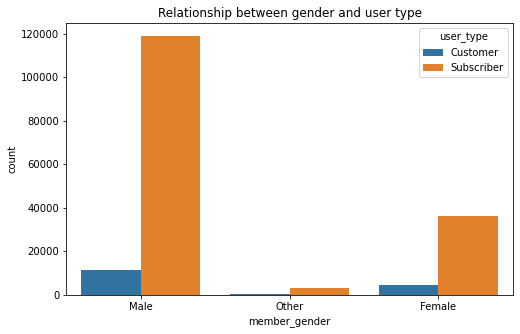

```python
# Relationship between user type and gender
plt.figure(figsize=(8,5))
sb.countplot(data=trip_clean_df, x='member_gender', hue='user_type');
plt.title('Relationship between gender and user type');
```

This plot also shows how we can visualize the relationship between the member gender and user type.

Next up: Relationship between age and gender.

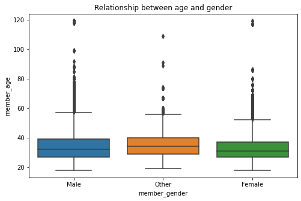

```python
# Relationship between age and gender
plt.figure(figsize=(8,5))
sb.boxplot(data = trip_clean_df, y='member_age', x = 'member_gender');
plt.title('Relationship between age and gender');
```

The mean of the age for members in other gender is higher than that of males and females.

Next up: Relationship between member age and user type.

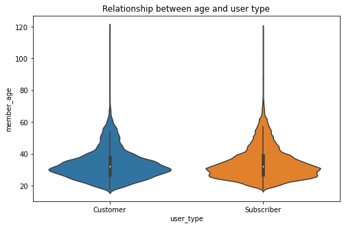

```python
# Relationship between member age and user type
plt.figure(figsize=(8,5))
sb.violinplot(data = trip_clean_df, x = 'user_type', y='member_age');
plt.title('Relationship between age and user type');
```

There is no significant difference in the mean ages for both customers and subscribers.

### Talk about some of the relationships you observed in this part of the investigation. How did the feature(s) of interest vary with other features in the dataset?

> Duration of rides seem to be dependent on age of users. And most of the duration are below 200 minutes. Some rides duration are as high as 1406 minutes, this may be as a result of riders forgetting to log off after using the bike.

### Did you observe any interesting relationships between the other features (not the main feature(s) of interest)?

> The number of male users is higher than female users in both subscribers and customers.

## Multivariate Exploration

> In this section, I will create plots of three or more variables to investigate the data even further.

> I will start by looking at the relationship between duration, age and gender.

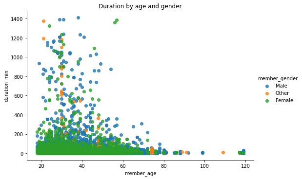

```python
# Realationship between duration, age and gender
g = sb.FacetGrid(data = trip_clean_df, hue = 'member_gender', height = 5, aspect = 1.5)
g.map(sb.regplot, 'member_age', 'duration_min', x_jitter= 0.04, fit_reg=False)
g.add_legend();
plt.title('Duration by age and gender');
```

We can see from the plot that the total number of points representing other gender is lesser than that of males and females. This confirms the univarate plot we have seen previously.

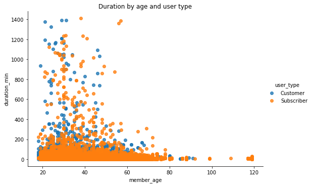

```python
# Realationship between duration, age and user type
g = sb.FacetGrid(data = trip_clean_df, hue = 'user_type', height = 5, aspect = 1.5)
g.map(sb.regplot, 'member_age', 'duration_min', x_jitter= 0.04, fit_reg=False)
g.add_legend();
plt.title('Duration by age and user type');
```

The plot shows that more of the user subscribers have less bike duration. Also larger number of users who are custosmers have ages below 60 years

### Talk about some of the relationships you observed in this part of the investigation. Were there features that strengthened each other in terms of looking at your feature(s) of interest?

> I have observed that regardless of the gender, users who are 60 years have less than 350 minutes bike durations. Also the least number of points shown by other gengers confirms that they are the least number of users in the system.

### Were there any interesting or surprising interactions between features?

> I was surprised to have observed that two female users with ages of 56 an 57 years have more than 1200 minutes bike duration. This maybe as result of not logging off after finnishing their ride.

## Conclusions

> From the explorations of the data, we have seen that bike duration is dependent on age where increase in user age leads to decrease in bike duration. We have also observed that even though there are more subscribers than customers in the system, Users who are customers turn to have longer bike duration than subscribers. Therfore, we might say that when users subscribe to the bikeshare system, it does not mean that they will have longer duration.